# General Preamble Code

```python
import numpy as np
import matplotlib.pyplot as plt
import pandas as pd
import mglearn
from IPython.display import display
```

# Additional Import Code for dataset W

```python
from ucimlrepo import fetch_ucirepo
# fetch dataset
wine_quality = fetch_ucirepo(id=186)
# data (as pandas dataframes)
X = wine_quality.data.features
y = wine_quality.data.targets['quality']
```

```python
# test
print(wine_quality.data)
```

```
{'ids': None, 'features':       fixed_acidity  volatile_acidity  citric_acid  residual_sugar  chlorides  \
0               7.4              0.70         0.00             1.9      0.076
1               7.8              0.88         0.00             2.6      0.098
2               7.8              0.76         0.04             2.3      0.092
3              11.2              0.28         0.56             1.9      0.075
4               7.4              0.70         0.00             1.9      0.076
...             ...               ...          ...             ...        ...
6492            6.2              0.21         0.29             1.6      0.039
6493            6.6              0.32         0.36             8.0      0.047
6494            6.5              0.24         0.19             1.2      0.041
6495            5.5              0.29         0.30             1.1      0.022
6496            6.0              0.21         0.38             0.8      0.020

      free_sulfur_dioxide  total_sulfur_dioxide  density    pH  sulphates  \
0                    11.0                  34.0  0.99780  3.51       0.56
```

[output cut: 80 more lines]

# Question 1

## How many red and white wines are in the dataset W?

```python
print("############ Assignment 1 Question 1 BEGIN ############")
print(wine_quality.data.original['color'].value_counts())
print("############ Assignment 1 Question 1 END ############")
```

```
############ Assignment 1 Question 1 BEGIN ############
color
white    4898
red      1599
Name: count, dtype: int64
############ Assignment 1 Question 1 END ############
```

# Question 2

## Let’s model quality as a “classification” problem first– where a wine could be classified into 10-point-scale quality integer score.

```python
print("############ Assignment 1 Question 2 BEGIN ############")
from sklearn.model_selection import train_test_split
X_train, X_test, y_train, y_test = train_test_split(X, y, test_size=0.25, train_size=0.75, random_state=0)
from sklearn.neighbors import KNeighborsClassifier
```

```
############ Assignment 1 Question 2 BEGIN ############
```

## 2a. What is the raw KNN score if you did a standard 75%/25% train/test split on the wine quality prediction with 1 neighbor?

```python
print("############ Assignment 1 Question 2a BEGIN ############")
clf = KNeighborsClassifier(n_neighbors=1)
clf.fit(X_train, y_train)
print("Test set predictions:", clf.predict(X_test))
print("Test set accuracy: {:.2f}".format(clf.score(X_test, y_test)))
print("############ Assignment 1 Question 2a END ############")
```

```
############ Assignment 1 Question 2a BEGIN ############
Test set predictions: [6 6 6 ... 5 6 5]
Test set accuracy: 0.58
############ Assignment 1 Question 2a END ############
```

## 2b. How does it change with 3 neighbors?

```python
print("############ Assignment 1 Question 2b BEGIN ############")
clf = KNeighborsClassifier(n_neighbors=3)
clf.fit(X_train, y_train)
print("Test set predictions:", clf.predict(X_test))
print("Test set accuracy: {:.2f}".format(clf.score(X_test, y_test)))
print("############ Assignment 1 Question 2b END ############")
```

```
############ Assignment 1 Question 2b BEGIN ############
Test set predictions: [6 6 6 ... 5 6 6]
Test set accuracy: 0.48
############ Assignment 1 Question 2b END ############
```

## 2c. With 5 neighbors?

```python
print("############ Assignment 1 Question 2c BEGIN ############")
clf = KNeighborsClassifier(n_neighbors=5)
clf.fit(X_train, y_train)
print("Test set predictions:", clf.predict(X_test))
print("Test set accuracy: {:.2f}".format(clf.score(X_test, y_test)))
print("############ Assignment 1 Question 2c END ############")
print("############ Assignment 1 Question 2 END ############")
```

```
############ Assignment 1 Question 2c BEGIN ############
Test set predictions: [6 6 6 ... 6 6 6]
Test set accuracy: 0.48
############ Assignment 1 Question 2c END ############
############ Assignment 1 Question 2 END ############
```

# Question 3

## Let’s model quality as a “regression” problem now– where a wine could get a floating point quality score (no rounding) on a 10-point-scale quality score.

```python
print("############ Assignment 1 Question 3 BEGIN ############")
from sklearn.neighbors import KNeighborsRegressor
X_train, X_test, y_train, y_test = train_test_split(X, y, test_size=0.25, train_size=0.75, random_state=0)
```

```
############ Assignment 1 Question 3 BEGIN ############
```

## 3a. What is the raw KNN score if you did a standard 75%/25% train/test split on the wine quality prediction with 1 neighbor?

```python
print("############ Assignment 1 Question 3a BEGIN ############")
reg = KNeighborsRegressor(n_neighbors=1)
reg.fit(X_train, y_train)
print("Test set predictions:\n", reg.predict(X_test))
print("Test set R^2: {:.2f}".format(reg.score(X_test, y_test)))
print("############ Assignment 1 Question 3a END ############")
```

```
############ Assignment 1 Question 3a BEGIN ############
Test set predictions:
 [6. 6. 6. ... 5. 6. 5.]
Test set R^2: -0.02
############ Assignment 1 Question 3a END ############
```

## 3b. With 3 neighbors?

```python
print("############ Assignment 1 Question 3b BEGIN ############")
reg = KNeighborsRegressor(n_neighbors=3)
reg.fit(X_train, y_train)
print("Test set predictions:\n", reg.predict(X_test))
print("Test set R^2: {:.2f}".format(reg.score(X_test, y_test)))
print("############ Assignment 1 Question 3b END ############")
```

```
############ Assignment 1 Question 3b BEGIN ############
Test set predictions:
 [5.66666667 6.         6.         ... 5.33333333 6.         5.66666667]
Test set R^2: 0.10
############ Assignment 1 Question 3b END ############
```

## 3c. With 5 neighbors?

```python
print("############ Assignment 1 Question 3c BEGIN ############")
reg = KNeighborsRegressor(n_neighbors=5)
reg.fit(X_train, y_train)
print("Test set predictions:\n", reg.predict(X_test))
print("Test set R^2: {:.2f}".format(reg.score(X_test, y_test)))
print("############ Assignment 1 Question 3c END ############")
```

```
############ Assignment 1 Question 3c BEGIN ############
Test set predictions:
 [5.6 6.4 5.6 ... 5.6 6.  5.6]
Test set R^2: 0.14
############ Assignment 1 Question 3c END ############
```

## 3d. At how many neighbors does the R-square hit its highest level?

```python
print("############ Assignment 1 Question 3d BEGIN ############")
print("At 5 neighbors, the R-square hit its highest level.")
print("############ Assignment 1 Question 3d END ############")
```

```
############ Assignment 1 Question 3d BEGIN ############
At 5 neighbors, the R-square hit its highest level.
############ Assignment 1 Question 3d END ############
```

# Question 4

## Now split red and white wines apart in the dataset and run KNNs again (you will have to do new test and train splits with random_state=0). Answer 2 and 3 again with this data split apart. Report your numbers for 2-4 in a table.

```python
print("############ Assignment 1 Question 4 BEGIN ############")
# split dataset by color
red_data = wine_quality.data.original['color'] == 'red'
white_data = wine_quality.data.original['color'] == 'white'

x_red = X[red_data]
y_red = y[red_data]
x_white = X[white_data]
y_white = y[white_data]

# init final results table
results = []

# function to loop KNN for classification and regression for each n neighbors
def run_knn_experiments(x_data, y_data, color):
    row = {'Color': color}
    # classification
    for n in [1, 3, 5]:
        x_tr, x_te, y_tr, y_te = train_test_split(x_data, y_data, test_size=0.25, train_size=0.75, random_state=0)
        clf = KNeighborsClassifier(n_neighbors=n)
        clf.fit(x_tr, y_tr)
        acc = clf.score(x_te, y_te)
        row[f'KNN Classifier (k={n})'] = acc
    # regression
    for n in [1, 3, 5]:
        x_tr, x_te, y_tr, y_te = train_test_split(x_data, y_data, test_size=0.25, train_size=0.75, random_state=0)
        reg = KNeighborsRegressor(n_neighbors=n)
        reg.fit(x_tr, y_tr)
        r2 = reg.score(x_te, y_te)
        row[f'KNN Regressor (k={n})'] = r2
    results.append(row)

# x_tr: training features, x_te: testing features, y_tr: training labels, y_te: testing labels

run_knn_experiments(x_red, y_red, 'Red')
run_knn_experiments(x_white, y_white, 'White')

results_df = pd.DataFrame(results)
display(results_df)
print("############ Assignment 1 Question 4 END ############")
```

```
############ Assignment 1 Question 4 BEGIN ############
```

|  | Color | KNN Classifier (k=1) | KNN Classifier (k=3) | KNN Classifier (k=5) | KNN Regressor (k=1) | KNN Regressor (k=3) | KNN Regressor (k=5) |
| --- | --- | --- | --- | --- | --- | --- | --- |
| 0 | Red | 0.60000 | 0.480000 | 0.470000 | -0.251649 | 0.056946 | 0.132845 |
| 1 | White | 0.54449 | 0.466939 | 0.459592 | -0.142143 | 0.096386 | 0.109148 |

```
############ Assignment 1 Question 4 END ############
```

# Question 5

## Does KNN Classifier treat Wine Quality like a nominal or ordinal variable? What about the KNN Regressor? Comment on each approach’s suitability based on this.

```python
print("############ Assignment 1 Question 5 BEGIN ############")
print("KNN Classifier treats Wine Quality like a nominal variable.")
print("The KNN Regressor treats Wine Quality like ordinal variable.")
print("KNN Regressor is better suited than KNN Classifier, because there is a clear, meaningful ranking. Higher wine qualities are better than lower values.")
print("KNN Classifier would treat each level of wine quality the same and as having no intrinsic order.")
print("############ Assignment 1 Question 5 END ############")
```

```
############ Assignment 1 Question 5 BEGIN ############
KNN Classifier treats Wine Quality like a nominal variable.
The KNN Regressor treats Wine Quality like ordinal variable.
KNN Regressor is better suited than KNN Classifier, because there is a clear, meaningful ranking. Higher wine qualities are better than lower values.
KNN Classifier would treat each level of wine quality the same and as having no intrinsic order.
############ Assignment 1 Question 5 END ############
```

# Question 6

## Visualize the “quality” variable in the overall dataset in terms of distribution across scores. Is there a class imbalance in this distribution? Does it imply that classification is likely to work better or regression? Why?

```
############ Assignment 1 Question 6 BEGIN ############
```

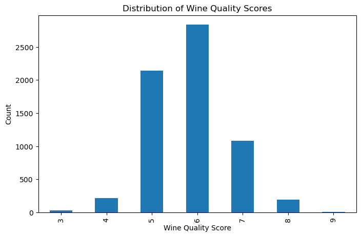

```
There is a class imbalance in the distribution of wine quality scores, as some quality scores have many more samples than others. This imbalance suggests that regression may be more appropriate than classification, as regression can handle ordinal variables better, while classification may struggle …
############ Assignment 1 Question 6 END ############
```

```python
print("############ Assignment 1 Question 6 BEGIN ############")
plt.figure(figsize=(8, 5))
wine_quality.data.targets['quality'].value_counts().sort_index().plot(kind='bar')
plt.xlabel('Wine Quality Score')
plt.ylabel('Count')
plt.title('Distribution of Wine Quality Scores')
plt.show()

print("There is a class imbalance in the distribution of wine quality scores, as some quality scores have many more samples than others. This imbalance suggests that regression may be more appropriate than classification, as regression can handle ordinal variables better, while classification may struggle with underrepresented classes.")
print("############ Assignment 1 Question 6 END ############")
```

# Question 7

## Research feature scaling. Does the fact that feature scaling was not allowed impact the results of the KNN classifier? Why or why not?

```python
print("############ Assignment 1 Question 7 BEGIN ############")
print("The fact that feature scaling was not allowed does impact the results of the KNN classifier, because the features of the dataset have vastly different magnitudes (ex: density is between 0-1, total sulfur dioxide can range between 0-200).")
print("############ Assignment 1 Question 7 END ############")
```

```
############ Assignment 1 Question 7 BEGIN ############
The fact that feature scaling was not allowed does impact the results of the KNN classifier, because the features of the dataset have vastly different magnitudes (ex: density is between 0-1, total sulfur dioxide can range between 0-200).
############ Assignment 1 Question 7 END ############
```

# Question 8

## How do you compare the “accuracy” score in the classifier with the “R-squared” score in the regressor? What might be a rule-of-thumb that will help you compare these evaluation metrics across the two algorithms?

```python
print("############ Assignment 1 Question 8 BEGIN ############")
print("You can't directly compare accuracy scores with R-squared scores since they measure two different things. An accuracy of 0.75 means the model correctly predicted the test data's class 75% of the time. An r-squared of 0.75 means the model can explain 75% of the variation in wine quality.")
print("For accuracy scoring, the performance is evaluated on a binary; the model is either right or it is wrong. For regression and r-squared, performance is graded by how far the model deviates from the true value. For classification, predicting a wine quality of 6 is the same as predicting 10 if the true value was 5. But for regression, the prediction of 6 is more correct than the 10.")
print("A rule-of-thumb is that accuracy makes more sense for nominal values and r-squared is better for ordinal or quantitative values. Instead of comparing the different metrics to each other, we should compare them our performance without a model (like only predicting the most common wine quality or the mean wine quality).")
print("############# Assignment 1 Question 8 END #############")
```

```
############ Assignment 1 Question 8 BEGIN ############
You can't directly compare accuracy scores with R-squared scores since they measure two different things. An accuracy of 0.75 means the model correctly predicted the test data's class 75% of the time. An r-squared of 0.75 means the model can explain 75% of the variation in wine quality.
For accuracy scoring, the performance is evaluated on a binary; the model is either right or it is wrong. For regression and r-squared, performance is graded by how far the model deviates from the true value. For classification, predicting a wine quality of 6 is the same as predicting 10 if the true…
A rule-of-thumb is that accuracy makes more sense for nominal values and r-squared is better for ordinal or quantitative values. Instead of comparing the different metrics to each other, we should compare them our performance without a model (like only predicting the most common wine quality or the …
############# Assignment 1 Question 8 END #############
```

# Question 9

## What do you observe on the difference between modeling this as a classification versus a regression problem across 1-4? Was there a big difference as one color was removed? What does this tell you? As the number of neighbors increases, which approach improves? Why do you think both these things are happening?

```python
print("############ Assignment 1 Question 9 BEGIN ############")
print("When modeling wine quality as a classification problem, the model treats each quality level as a separate, unordered class. In regression, the model recognizes the ordinal nature of quality, allowing it to predict intermediate values and better capture the ranking between qualities.")
print("When running the model with one color removed (i.e. training on only red data or only white data) we found that the resulting models had different performances (indicated by different accuracy scores and R-squared). This suggests that color is an important feature and that the dataset's balance affects model performance.")
print("As the number of neighbors increases, the regression approach tends to improve more consistently, as it benefits from averaging over more samples, reducing variance. In classification, increasing neighbors can sometimes hurt performance if the classes are imbalanced or not well separated. These effects occur because regression leverages the ordinal relationship in the target, while classification does not.")
print("############ Assignment 1 Question 9 END ############")
```

```
############ Assignment 1 Question 9 BEGIN ############
When modeling wine quality as a classification problem, the model treats each quality level as a separate, unordered class. In regression, the model recognizes the ordinal nature of quality, allowing it to predict intermediate values and better capture the ranking between qualities.
When running the model with one color removed (i.e. training on only red data or only white data) we found that the resulting models had different performances (indicated by different accuracy scores and R-squared). This suggests that color is an important feature and that the dataset's balance affe…
As the number of neighbors increases, the regression approach tends to improve more consistently, as it benefits from averaging over more samples, reducing variance. In classification, increasing neighbors can sometimes hurt performance if the classes are imbalanced or not well separated. These effe…
############ Assignment 1 Question 9 END ############
```